# Predictive analysis for heart disease diagnosis

## READ DATA

Firstly, we install any required package and read the related library.

```r
#install.packages('readr')
#install.packages('ggplot2')
#install.packages('mlbench')
#install.packages('corrplot')
#install.packages('Amelia')
#install.packages('caret')
#install.packages('plotly')
#install.packages('caTools')
#install.packages('reshape2')
#install.packages('dplyr')
#install.packages("e1071")
#install.packages("randomforest")
#install.packages("car")
#install.packages("gbm")
library(MASS)
library(readr)
library(ggplot2)
library(corrplot)
library(mlbench)
library(Amelia)
library(plotly)
library(reshape2)
library(caret)
library(caTools)
library(dplyr)
library(tree)
library(randomForest)
library(car)
library(gbm)
```

Then, we read the data and rename a misspelled column.

Attribute Information:

1. age
2. sex
3. chest pain type (4 values)
4. resting blood pressure
5. serum cholestoral in mg/dl
6. fasting blood sugar > 120 mg/dl
7. resting electrocardiographic results (values 0,1,2)
8. maximum heart rate achieved
9. exercise induced angina
10. oldpeak = ST depression induced by exercise relative to rest
11. the slope of the peak exercise ST segment
12. number of major vessels (0-3) colored by flourosopy
13. thal: 3 = normal; 6 = fixed defect; 7 = reversable defect

```r
heart <- read.csv('heart.csv', na.strings = "N/A")
names(heart)[which(names(heart) == "ï..age")] <- "age"
```

Check for missing values:

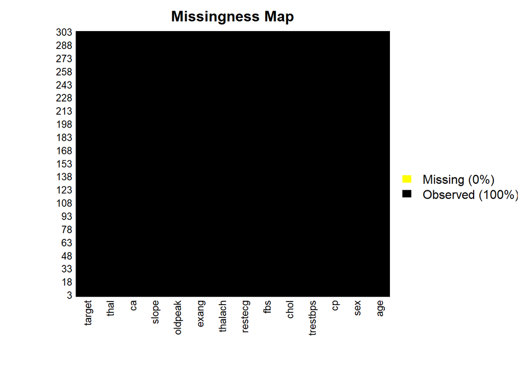

```r
missmap(heart,col=c('yellow','black'),legend=TRUE)
```

There is not any missing value.

## Distribution

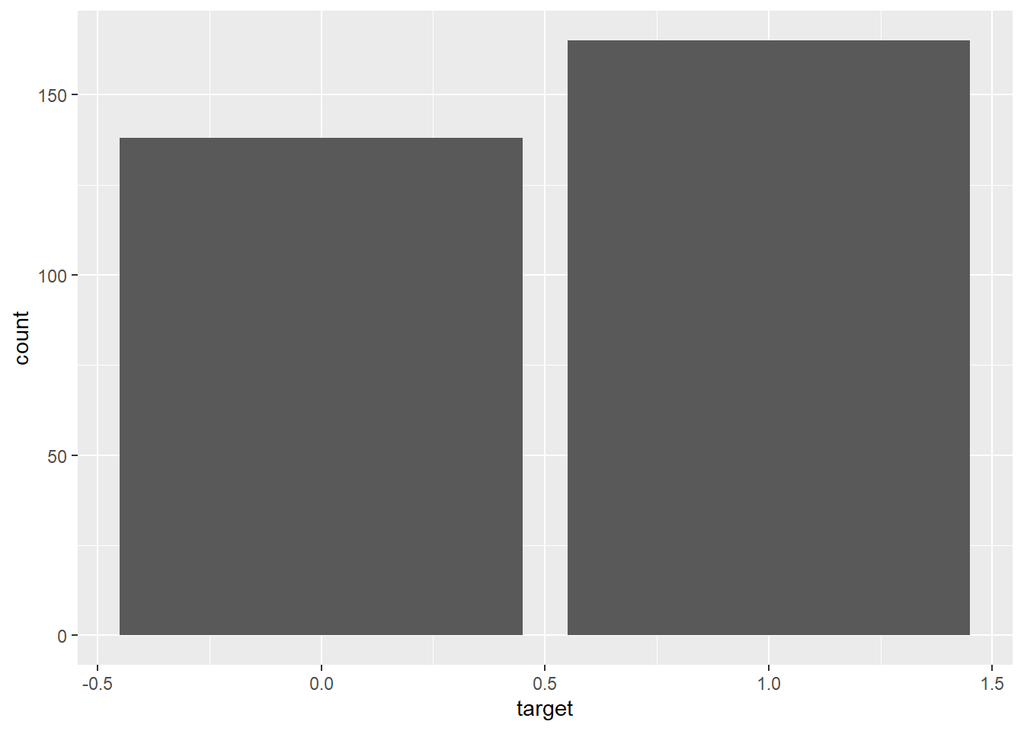

```r
ggplot(data = heart) +
    geom_bar(mapping = aes(x=target))
```

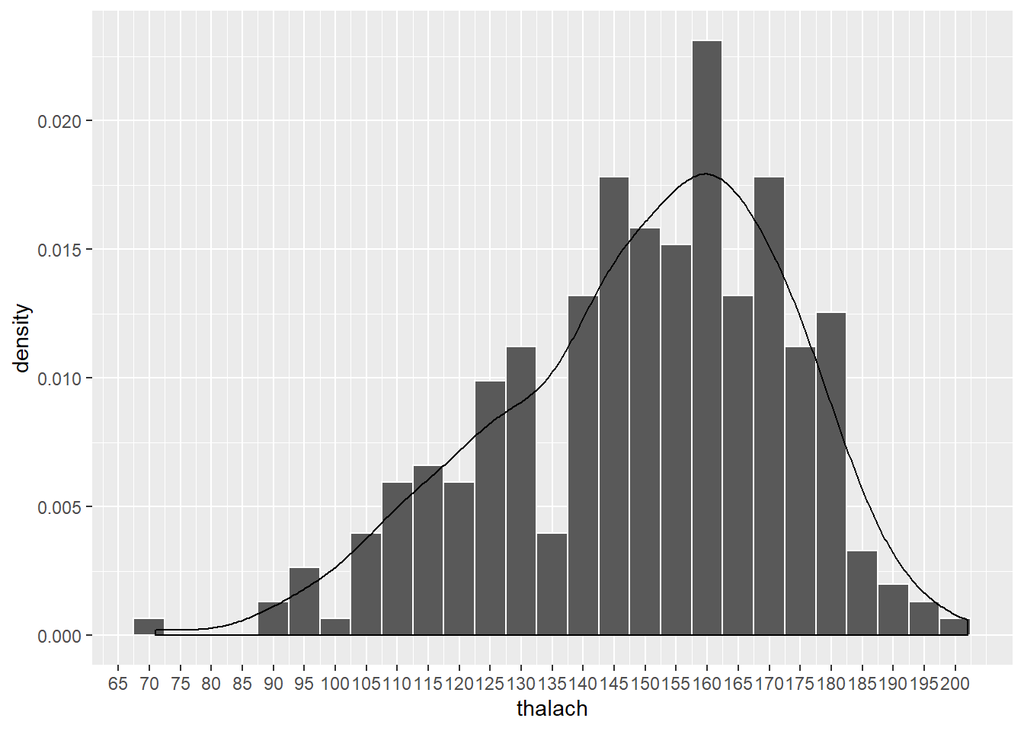

```r
ggplot(heart, aes(x = thalach)) +
  scale_x_continuous(breaks = seq(50,200,5)) +
  geom_histogram(aes(y = ..density..), binwidth = 5, color = 'white') +
  geom_density()
```

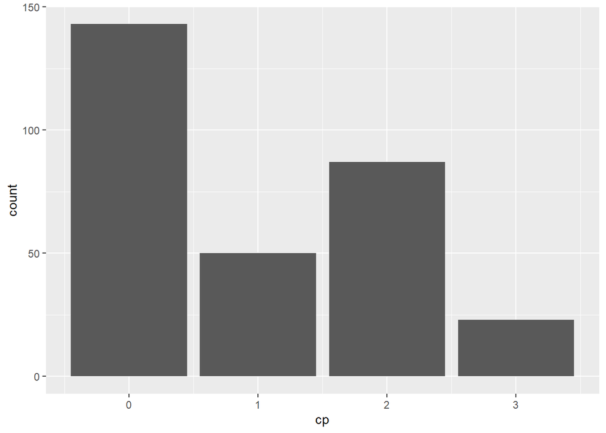

```r
ggplot(data = heart) +
    geom_bar(mapping = aes(x=cp))
```

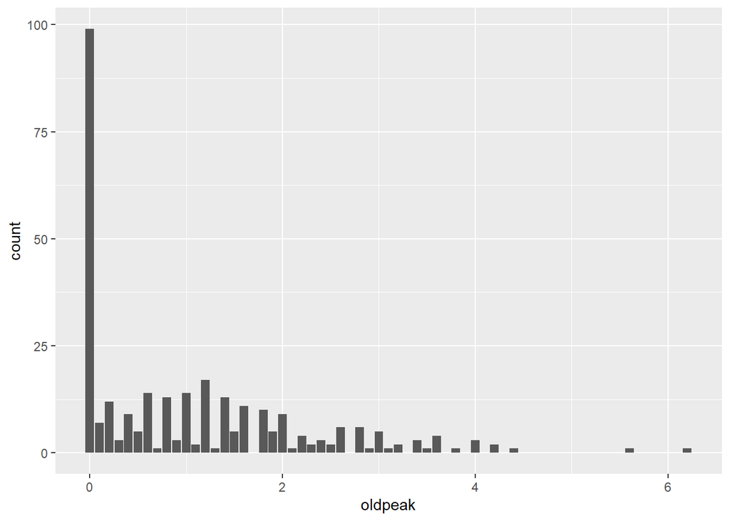

```r
ggplot(data = heart) +
    geom_bar(mapping = aes(x=oldpeak))
```

The response “target” is not normally distributed as it only has two values (0-no presence and 1-presence) the number of people suffering heart attack is a bit larger than the number of healthy people.

## Correlations

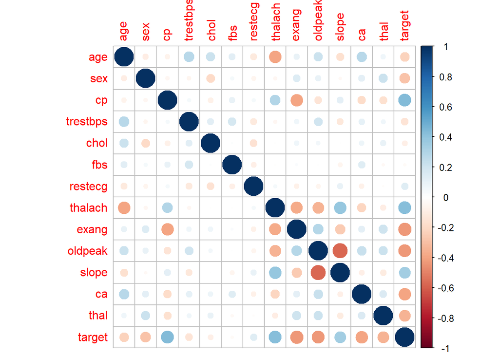

```r
heart_num <- select_if(heart, is.numeric)
corrplot(cor(heart_num))
```

```r
cor.test(~slope + oldpeak, data=heart)
```

```
##
##  Pearson's product-moment correlation
##
## data:  slope and oldpeak
## t = -12.274, df = 301, p-value < 2.2e-16
## alternative hypothesis: true correlation is not equal to 0
## 95 percent confidence interval:
##  -0.6480430 -0.4972154
## sample estimates:
##        cor
## -0.5775368
```

From the graph, we can see all the predictors except “resting blood pressure” (trestbps), “serum cholestoral in mg/dl”(chol), “fasting blood sugar > 120 mg/dl”(fbs), “resting electrocardiographic results (values 0,1,2)”(restecg) are correlated to the response.

Slope and oldpeak are strongly correlated to each other. From the graph and the correlation test. we can see:

The estimated correlation from the sample is -0.578 The 95% confidence limit for the population correlation is between -0.648 to -0.497. The probability of finding a correlation value this far from zero under the null hypothesis (both variables independent and distributed normally) is 2.2e-16 (a very small number!). Therefore we find evidence to reject the null hypothesis at the 5% significance level, and accept the hypothesis that the predictors slope and oldpeak are strongly correlated.

Other predictors are not strongly correlated to each other.

## Relationship

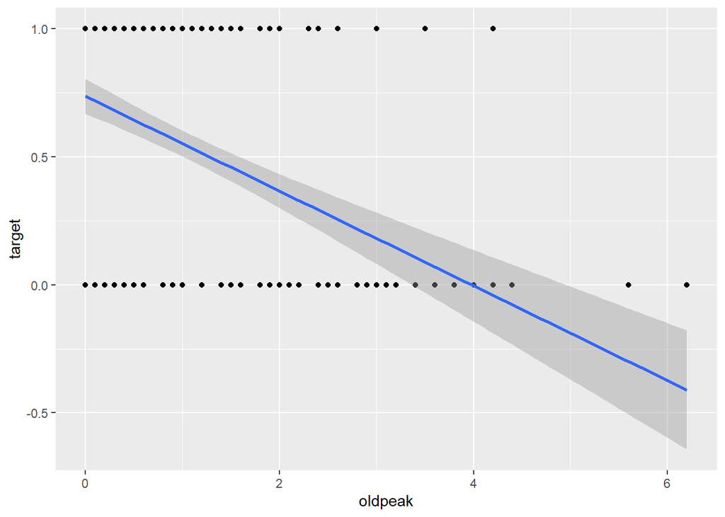

```r
ggplot(data = heart, aes( x = oldpeak, y = target)) +
  geom_point() +
  geom_smooth(method = "lm")
```

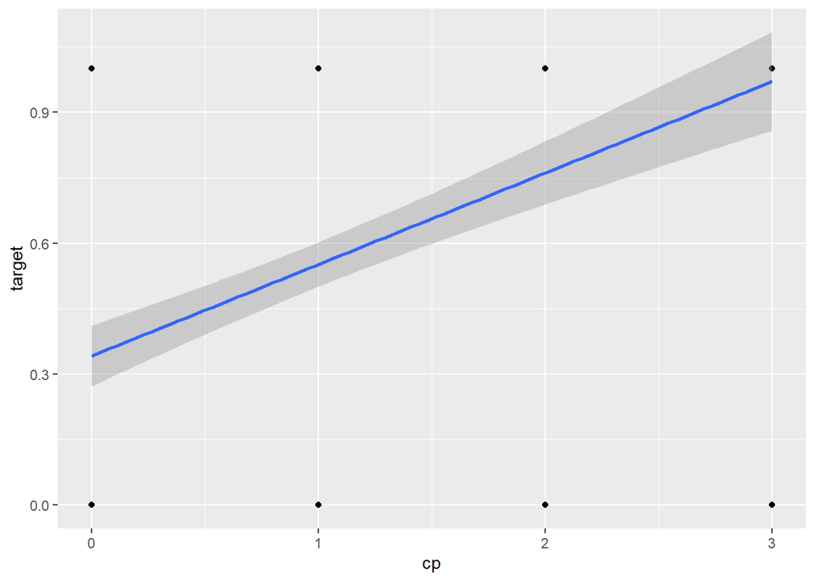

```r
ggplot(data = heart, aes( x = cp, y = target)) +
  geom_point() +
  geom_smooth(method = "lm")
```

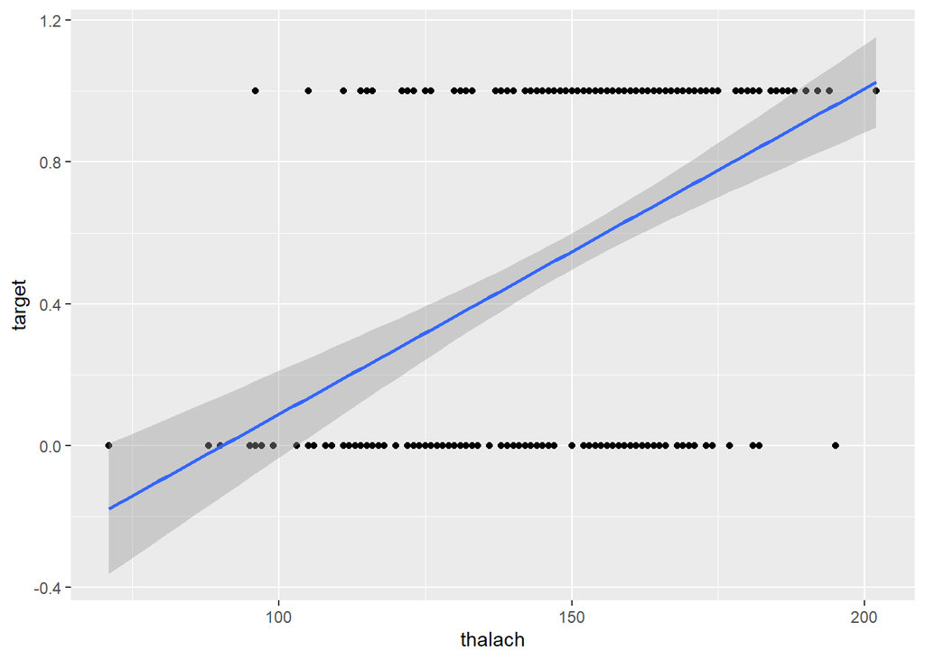

```r
ggplot(data = heart, aes( x = thalach, y = target)) +
  geom_point() +
  geom_smooth(method = "lm")
```

The only issue we observed is the strong correlation between slope and oldpeak which could cause issues due to collinearity. we will talk about this later.

Except trestbps, chol, fbs, restecg, all the predictors may be good predictors as they are all correlated to the response significantly.

## T-test

```r
t.test(target~ fbs, mu = 0, alt = "two.sided", conf = 0.95, data=heart)
```

```
##
##  Welch Two Sample t-test
##
## data:  target by fbs
## t = 0.48193, df = 59.891, p-value = 0.6316
## alternative hypothesis: true difference in means is not equal to 0
## 95 percent confidence interval:
##  -0.1237496  0.2023025
## sample estimates:
## mean in group 0 mean in group 1
##       0.5503876       0.5111111
```

#Transfer the data

```r
heart$target2 <- factor(heart$target, levels = c("0","1"), labels = c("No", "Yes"))
vif(lm(target ~ .-target2, data = heart))
```

```
##      age      sex       cp trestbps     chol      fbs  restecg  thalach
## 1.443474 1.161866 1.284456 1.170591 1.150174 1.087379 1.060998 1.613726
##    exang  oldpeak    slope       ca     thal
## 1.402001 1.705857 1.642595 1.202570 1.147279
```

Firstly, we convert the response target to factor column for the following LDA. Then, we use vif function to see if there is any collinearity issue. However, none of a VIF is larger than 5 or 10, so the predictor is more related the response than it is to the other predictors.

## LDA

```r
set.seed(123)

heartSplit <- sample(seq_len(nrow(heart)), 0.5 * nrow(heart))
Train <- heart[heartSplit, ]
Test <- heart[-heartSplit, ]

lda.single= lda(target2 ~ thalach -target, data = Train)
lda.single.prediction <- predict(lda.single, newdata= Test)$class
table(predicted=lda.single.prediction,actual=Test$target2)
```

```
##          actual
## predicted No Yes
##       No  34  13
##       Yes 41  64
```

```r
lda.intermediate= lda(target2 ~ thalach + cp + oldpeak -target, data = Train)
lda.intermediate.prediction <- predict(lda.intermediate, newdata= Test)$class
table(predicted=lda.intermediate.prediction,actual=Test$target2)
```

```
##          actual
## predicted No Yes
##       No  46   7
##       Yes 29  70
```

```r
lda.full = lda(target2 ~ .-target, data = Train)
lda.full.prediction <- predict(lda.full, newdata= Test)$class
table(predicted=lda.full.prediction,actual=Test$target2)
```

```
##          actual
## predicted No Yes
##       No  54   3
##       Yes 21  74
```

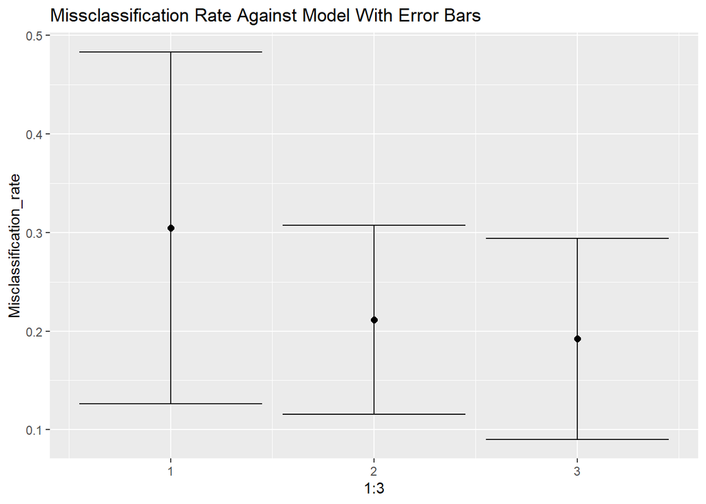

```r
set.seed(123)
cv_model1 <- train(
  target2 ~ thalach -target, data = Train,
  method = "lda",
  trControl = trainControl(method = "cv", number = 10)
)

set.seed(123)
cv_model2 <- train(
  target2 ~ thalach + cp + oldpeak -target, data = Train,
  method = "lda",
  trControl = trainControl(method = "cv", number = 10)
)

set.seed(123)
cv_model3 <- train(
  target2 ~ .-target, data = Train,
  method = "lda",
  trControl = trainControl(method = "cv", number = 10)
)

model_set = list(
  model1 = cv_model1,
  model2 = cv_model2,
  model3 = cv_model3
)
results <- data.frame(summary(resamples(model_set))$statistics$Accuracy)
results <- mutate(results, Misclassification_rate = (1-Mean)) #Calculating missclasification rate
results <- mutate(results, Error_bars = (X3rd.Qu. - X1st.Qu.)) #Error bars


results <- mutate(results, ymin = (Misclassification_rate - Error_bars ))
results <- mutate(results, ymax = (Misclassification_rate + Error_bars ))

ggplot(results, aes(x = 1:3, y=Misclassification_rate)) +
    geom_point(size = 2) +
    geom_errorbar(aes(ymin = ymin, ymax = ymax, y=))+ ggtitle("Missclassification Rate Against Model With Error Bars")#With error bars
```

From the graph, we can see that the full predictor model with error bars has the lowest misclassification rate.So it is the optimum model.

We evaluate performance of chosen model on test dataset:

```r
lda.full = lda(target2 ~ .-target, data = Train)
lda.full.prediction <- predict(lda.full, newdata= Test)$class
table(predicted=lda.full.prediction,actual=Test$target2)
```

```
##          actual
## predicted No Yes
##       No  54   3
##       Yes 21  74
```

```r
misclassified = sum(lda.full.prediction!=Test$target2)
misclassification_rate_lda = misclassified/nrow(Test)
misclassification_rate_lda
```

```
## [1] 0.1578947
```

There are 54+21=75 people without heart attack, and 74+3=77 people with heart attack, but the model predicts that there are 54 people without heart attack and 74 people with heart attack. The misclassification rate is 15.79%.

An important thing to notice is that the misclassification rate of factor “no” is much higher than the misclassification rate of factor “yes”.

## Pruning decision tree

```r
set.seed(123)
train <- sample(1:nrow(heart),nrow(heart)/2)
heart.test <- heart[-train, ]

tree.heart <- tree(target2 ~ .-target, data = heart, subset= train)

set.seed(3)
cv.heart <- cv.tree(tree.heart, FUN = prune.misclass)
cv.heart
```

```
## $size
## [1] 15  9  4  2  1
##
## $dev
## [1] 35 35 33 50 69
##
## $k
## [1] -Inf  0.0  1.6  7.5 24.0
##
## $method
## [1] "misclass"
##
## attr(,"class")
## [1] "prune"         "tree.sequence"
```

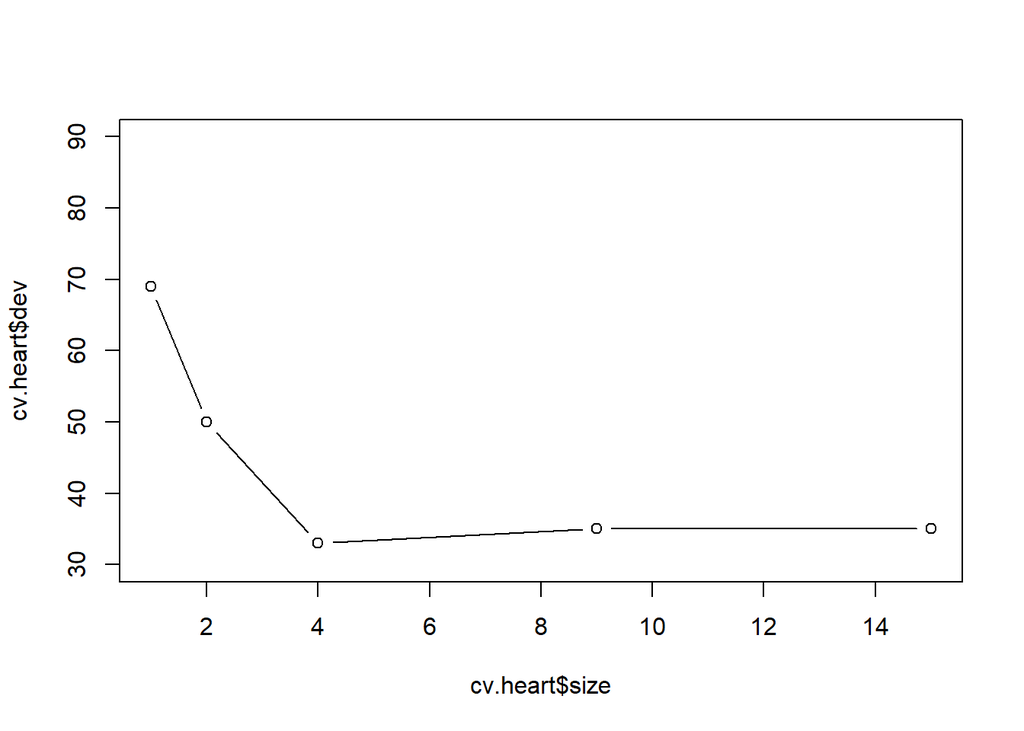

```r
N <- length(cv.heart$size)-2
size_vals <- cv.heart$size[1:N]
mc <- rep(0,N)

for (i in 1:N){
   prune.heart <- prune.misclass(tree.heart, best = size_vals[i])
   tree.pred <- predict(prune.heart, heart.test, type = "class")
   mc[i] <- sum(tree.pred != heart.test$target)
 }

plot(cv.heart$size, cv.heart$dev,
     type = "b", ylim= c(30,90))
points(size_vals,mc, col='red')
```

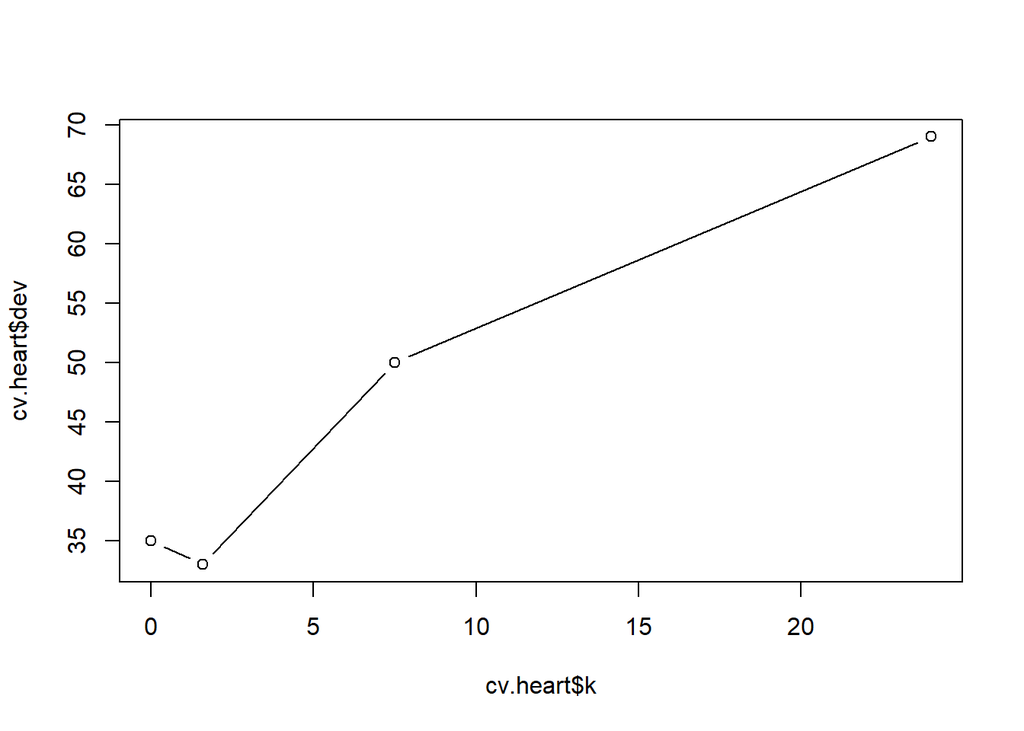

```r
plot(cv.heart$k, cv.heart$dev, type = "b")
```

Looking at the information stored we can access in the cv result, we found that the tree with 4 terminal nodes results in the lowest cross-validation error rate, with 33 cross-validation errors.

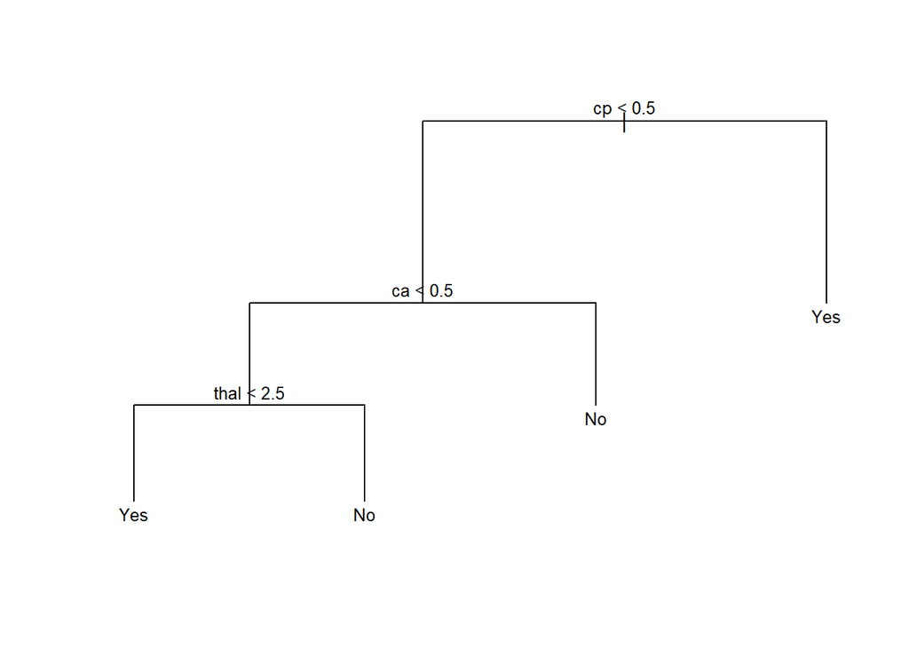

```r
prune.heart <- prune.misclass(tree.heart, best = 4)
plot(prune.heart)
text(prune.heart,cex=.8)
```

```r
tree.pred <- predict(prune.heart, heart.test, type = "class")
table(predicted=tree.pred, actual=heart.test$target2)
```

```
##          actual
## predicted No Yes
##       No  51   5
##       Yes 24  72
```

```r
misclassified = sum(tree.pred!=heart.test$target2)
misclassification_rate = misclassified/nrow(heart.test)
misclassification_rate
```

```
## [1] 0.1907895
```

We can see the misclassification rate of the best performing pruning decision tree is 19.08%.

## Bagging decision tree

```r
set.seed(1)
p <- 13
heart_test <- heart[-train, "target"]
bag.heart <- randomForest(target2 ~ .-target, data = heart, subset = train, mtry = 13, importance = TRUE)
yhat.bag <- predict(bag.heart, newdata = heart[-train, ],type = "class")
table(yhat.bag, heart_test)
```

```
##         heart_test
## yhat.bag  0  1
##      No  52  6
##      Yes 23 71
```

```r
rf_tree = randomForest(target2~.-target, data = heart, mtry=p, ntree = 5000, do.trace=100)
```

```
## ntree      OOB      1      2
##   100:  20.13% 26.09% 15.15%
##   200:  21.45% 28.26% 15.76%
##   300:  22.11% 26.81% 18.18%
##   400:  21.78% 27.54% 16.97%
##   500:  20.79% 26.81% 15.76%
##   600:  21.45% 27.54% 16.36%
##   700:  22.44% 28.99% 16.97%
##   800:  22.44% 28.99% 16.97%
##   900:  21.12% 26.81% 16.36%
##  1000:  20.46% 26.09% 15.76%
##  1100:  20.79% 26.81% 15.76%
##  1200:  21.12% 26.81% 16.36%
##  1300:  21.45% 26.81% 16.97%
##  1400:  21.78% 27.54% 16.97%
```

[output cut: 36 more lines]

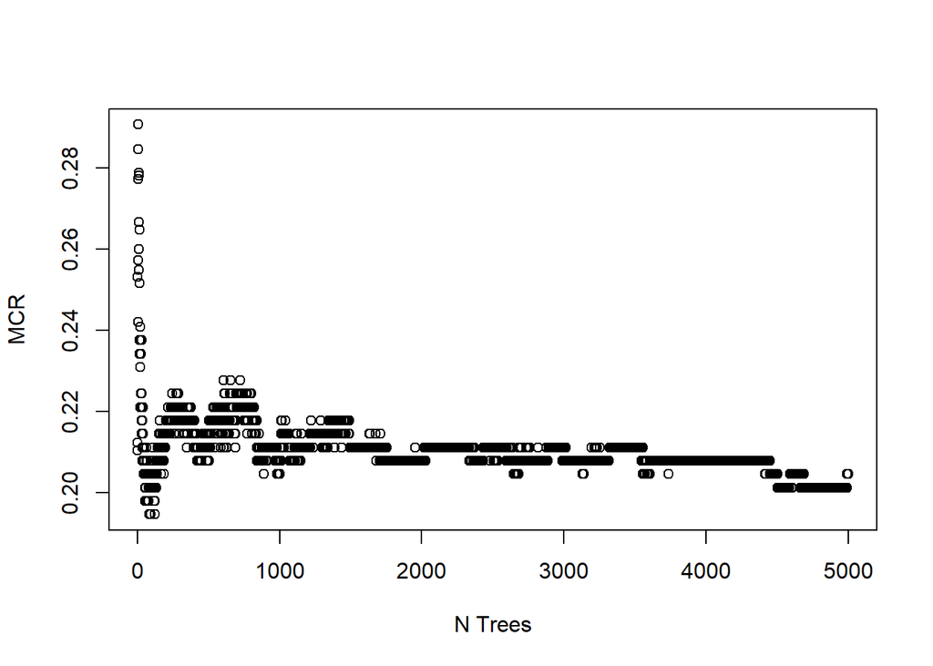

```r
# rf_tree$mse stores the MSE calculated on the Out-Of-Bag
plot(rf_tree$err.rate[,1], xlab="N Trees", ylab="MCR")
```

From the result and plot of OOB performance, we can see that when ntree = 100, 4600, 4700, 4800 and 4900, OOB reaches its minimum. So we choose ntree=4600 to build the optimal decision tree as ntree=100 is small which will make the result of model unstable.

```r
bag.heart <- randomForest(target2 ~ .-target, data = heart, subset = train, mtry = 13, importance = TRUE, ntree= 4600)
yhat.bag <- predict(bag.heart, newdata = heart[-train, ])
table(predicted=yhat.bag, actual=heart_test)
```

```
##          actual
## predicted  0  1
##       No  52  6
##       Yes 23 71
```

```r
#the misclassification rate
misclassified = sum(yhat.bag!=heart.test$target2)
misclassification_rate = misclassified/nrow(heart.test)
misclassification_rate
```

```
## [1] 0.1907895
```

We can see the misclassification rate of the best performing bagging decision tree is 19.08%.

## Summary

```r
#LDA Model

table(predicted=lda.full.prediction,actual=Test$target2)
```

```
##          actual
## predicted No Yes
##       No  54   3
##       Yes 21  74
```

```r
misclassified = sum(lda.full.prediction!=Test$target2)
misclassification_rate_lda = misclassified/nrow(Test)
misclassification_rate_lda
```

```
## [1] 0.1578947
```

```r
#Pruning decision tree

table(predicted=tree.pred, actual=heart.test$target2)
```

```
##          actual
## predicted No Yes
##       No  51   5
##       Yes 24  72
```

```r
misclassified = sum(tree.pred!=heart.test$target2)
misclassification_rate = misclassified/nrow(heart.test)
misclassification_rate
```

```
## [1] 0.1907895
```

```r
#Bagging decision tree

table(predicted=yhat.bag, actual=heart_test)
```

```
##          actual
## predicted  0  1
##       No  52  6
##       Yes 23 71
```

```r
misclassified = sum(yhat.bag!=heart.test$target2)
misclassification_rate = misclassified/nrow(heart.test)
misclassification_rate
```

```
## [1] 0.1907895
```